# Sample size solutions for $N = 1$ intensive longitudinal designs

Authors

Ginette Lafit

Jordan Revol

Published

June 8, 2023

## Settings things up

Before we proceed, we need to ensure we have several packages installed and loaded into our `R` session. For the scripts below, we will use the following packages:

- [`data.table`](https://CRAN.R-project.org/package=data.table)
- [`psych`](https://CRAN.R-project.org/package=psych)
- [`tidyverse`](https://CRAN.R-project.org/package=tidyverse)
- [`MASS`](https://CRAN.R-project.org/package=MASS)

Which we can install in one go as follows:

```r
# Prepare the package list.
packages = c("data.table", "psych", "tidyverse", "MASS")

# Install packages.
install.packages(packages)
```

**Tip**

You may consider first checking if the packages are installed before actually installing them. Nevertheless, the code above will not reinstall packages that are already installed and up-to-date.

Now that we have all packages installed, we continue by loading them.

```r
# To create lagged outcome variables.
library(data.table)

# To compute descriptive statistics.
library(psych)

# A useful package.
library(tidyverse)

# Handy functions for data analysis.
library(MASS)

# Set a seed for reproducibility.
set.seed(123)
```

## Description

In this tutorial, we use data from Heininga et al. (2019). In this study, the authors applied the ESM methodology to study emotion dynamics in people with *Major Depressive Disorder* (MDD). The study consist of an ESM testing period of seven days in which participants had to fill out questions about mood and social context on their daily lives ten times a day (i.e., $70$ measurement occasions). The data set contains $38$ participants diagnosed with MDD and $40$ control subjects. Participants filled out the ESM questionnaires in a stratified random interval scheme between 9:30 AM and 9:30 PM.

First, we are going to load the data set:

```r
# Load the data set.
load(file = "assets/data/clinical-dataset.RData")
```

**Tip**

Make sure you load the data from the location where you downloaded it. If your analysis script (i.e., the `.R` file) and the dataset are in the same location, than you can simply load the data as follows:

```r
load(file = "clinical-dataset.RData")
```

## Data exploration

In this section we will explore briefly the variables in the data set.

### Data structure

Now, that we have the data ready, we can start by exploring it to get a better understanding of the variable measured.

```r
# Select the first participant diagnosed with MDD.
i.ID <- unique(data$PID[data$MDD == 1])[1]

# Select data from participant with person identification number `101`.
data <- data[data$PID == 101, ]
```

**Note**

From now on we will work with data from participant `101` only. In other words, `data` is now a subset of the original data set, containing only the responses from participant `101`.

```r
# Find the dimensions.
dim(data)
```

```
[1] 70  8
```

```r
# Find the structure.
str(data)
```

```
'data.frame':   70 obs. of  8 variables:
 $ PID      : num  101 101 101 101 101 101 101 101 101 101 ...
 $ day      : num  1 1 1 1 1 1 1 1 1 1 ...
 $ daybeep  : num  1 2 3 4 5 6 7 8 9 10 ...
 $ PA       : num  NA 27.3 49.7 43 43 ...
 $ NA.      : num  NA 30.4 23.8 24.2 32.8 19.6 18.4 21.2 23 21.8 ...
 $ anhedonia: num  NA 26 25 25 50 21 42 30 22 30 ...
 $ MDD      : num  1 1 1 1 1 1 1 1 1 1 ...
 $ QIDS     : num  12 12 12 12 12 12 12 12 12 12 ...
```

```r
# See the first 6 rows.
head(data)
```

```
  PID day daybeep       PA  NA. anhedonia MDD QIDS
1 101   1       1       NA   NA        NA   1   12
2 101   1       2 27.33333 30.4        26   1   12
3 101   1       3 49.66667 23.8        25   1   12
4 101   1       4 43.00000 24.2        25   1   12
5 101   1       5 43.00000 32.8        50   1   12
6 101   1       6 18.00000 19.6        21   1   12
```

```r
# See the last 6 rows.
tail(data)
```

```
   PID day daybeep       PA  NA. anhedonia MDD QIDS
65 101   7       5 24.33333 31.8        52   1   12
66 101   7       6 28.66667 20.6        53   1   12
67 101   7       7 23.33333 23.8        51   1   12
68 101   7       8 33.66667 36.2        46   1   12
69 101   7       9 41.66667 21.0        29   1   12
70 101   7      10 34.00000 18.4        47   1   12
```

```r
# Find the column names.
names(data)
```

```
[1] "PID"       "day"       "daybeep"   "PA"        "NA."       "anhedonia"
[7] "MDD"       "QIDS"
```

```r
# Summary of the data.
summary(data)
```

```
      PID           day       daybeep           PA             NA.
 Min.   :101   Min.   :1   Min.   : 1.0   Min.   :14.67   Min.   :14.40
 1st Qu.:101   1st Qu.:2   1st Qu.: 3.0   1st Qu.:26.08   1st Qu.:21.40
 Median :101   Median :4   Median : 5.5   Median :33.33   Median :25.90
 Mean   :101   Mean   :4   Mean   : 5.5   Mean   :33.51   Mean   :29.62
 3rd Qu.:101   3rd Qu.:6   3rd Qu.: 8.0   3rd Qu.:41.67   3rd Qu.:36.25
 Max.   :101   Max.   :7   Max.   :10.0   Max.   :57.33   Max.   :65.60
                                          NA's   :6       NA's   :6
   anhedonia          MDD         QIDS
 Min.   :14.00   Min.   :1   Min.   :12
 1st Qu.:24.75   1st Qu.:1   1st Qu.:12
 Median :41.50   Median :1   Median :12
 Mean   :39.34   Mean   :1   Mean   :12
 3rd Qu.:52.00   3rd Qu.:1   3rd Qu.:12
 Max.   :83.00   Max.   :1   Max.   :12
 NA's   :6
```

```r
# Number of participants.
length(unique(data$PID))
```

```
[1] 1
```

The data set contains the following variables:

- `PID` that denotes the individual identification number
- `day` is a variable that ranges from 1 to 7 and identifies the day of ESM testing
- `daybeep` is a variable that ranges from 1 to 10 and identifies the number of the prompt or beep within a day
- `PA` is the *Positive Affect* computed as the mean of items:
  - *How happy do you feel at the moment?*
  - *How relaxed do you feel at the moment?*
  - *How euphoric do you feel at the moment?*
- `NA.` is the *Negative Affect* computed as the mean of items:
  - *How depressed do you feel at the moment?*
  - *How stressed do you feel at the moment?*
  - *How anxious do you feel at the moment?*
  - *How angry do you feel at the moment?*
  - *How restless do you feel at the moment?*
- `anhedonia` corresponds to the ESM item:
  - *To what degree do you find it difficult to experience pleasure in activities at the moment?*
- `MDD` is a dummy variable equal to one when the individual has been diagnosed with MDD and 0 otherwise
- `QIDS` denotes the sum of the items of the *Quick Inventory of Depressive Symptomatology* (QIDS; Rush et al., 2003). QIDS was measured before the ESM testing period.

**Note**

Time-varying variables (PA, NA, and anhedonia) have been lagged within days to account for the night breaks.

### Descriptive statistics and visualizations

We first obtain some descriptive statistics including number of observations per day, and compliance.

```r
# Get the number of assessment per day.
table(data$PID)
```

```
101
 70
```

```r
# Compute a binary variable indicating if a participant answered a beep. We take
# the ESM item PA as reference because in this ESM design participants were not
# allowed to skip items.
data$Compliance <- ifelse(is.na(data$PA) == FALSE, 1, 0)

# Mean, median of the compliance for the participant PID=101
describe(data$Compliance)
```

```
   vars  n mean   sd median trimmed mad min max range skew kurtosis   se
X1    1 70 0.91 0.28      1       1   0   0   1     1 -2.9     6.48 0.03
```

Next, we can obtain visualizations and statistics of the distribution of the person-level or time-invariant variables variables.

```r
# We create a data set that will aggregate the data by the time invariant
# variables, i.e., the MDD diagnosis and QIDS depression score.
dt.person = aggregate(
    cbind(data$MDD, data$QIDS),
    by = list(data$PID),
    mean,
    na.rm = TRUE
)

# Add column names to the aggregated data set.
colnames(dt.person) = c("Group.1", "MDD", "QIDS")

# Print the aggregated data set.
dt.person
```

```
  Group.1 MDD QIDS
1     101   1   12
```

We now focus on time-varying variables NA, PA, and anhedonia and we obtain visualization and descriptive statistics

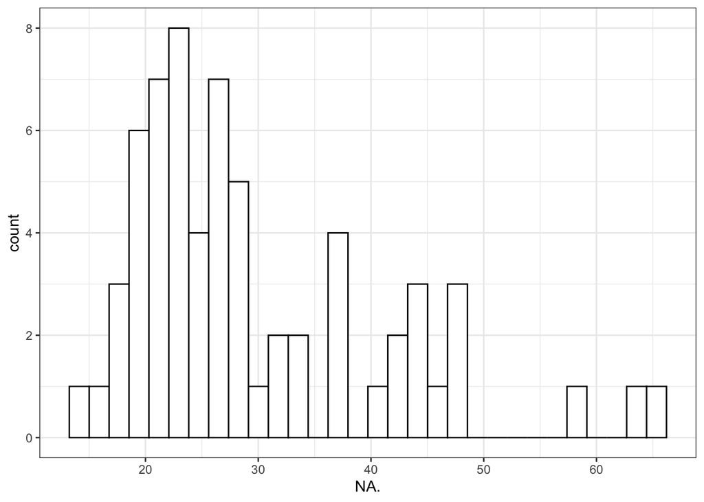

```r
# Histogram for the time-varying variable negative affect (NA.).
ggplot(data, aes(NA.)) +
    geom_histogram(
        color = "black",
        fill = "white",
        bins = 30
    ) +
    theme_bw()
```

```r
# Descriptive statistics for NA.
describe(data$NA.)
```

```
   vars  n  mean    sd median trimmed  mad  min  max range skew kurtosis   se
X1    1 64 29.62 11.47   25.9   28.13 7.86 14.4 65.6  51.2 1.25     1.01 1.43
```

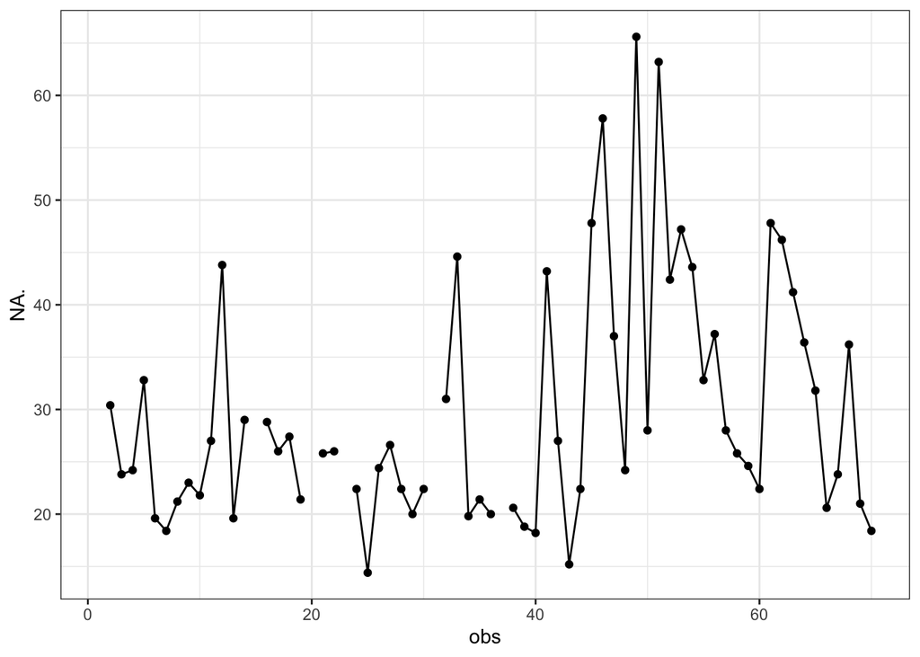

```r
# Create obs order variable.
data$obs = 1:nrow(data)

# Plot the trajectories of the time-varying variable NA by person.
data %>%
    ggplot(aes(x = obs, y = NA.)) +
    geom_point() +
    geom_line() +
    theme_bw()
```

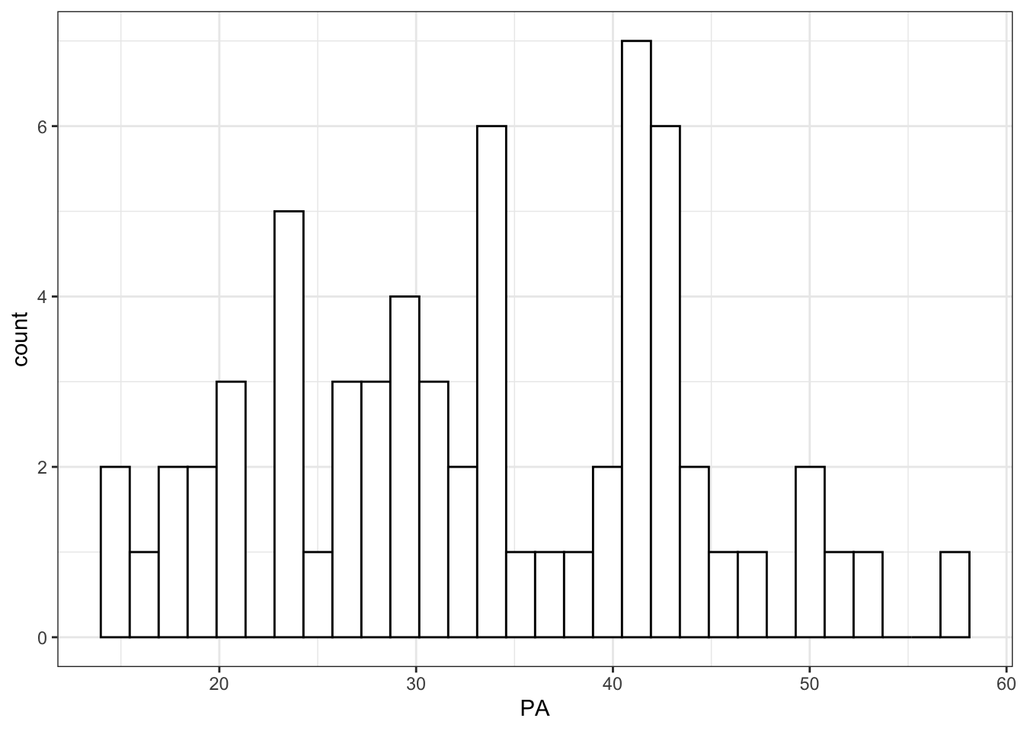

```r
# Histogram for the time-varying variable negative affect (PA).
ggplot(data, aes(PA)) +
    geom_histogram(
        color = "black",
        fill = "white",
        bins = 30
    ) +
    theme_bw()
```

```r
# Descriptive statistics for PA.
describe(data$PA)
```

```
   vars  n  mean    sd median trimmed   mad   min   max range skew kurtosis
X1    1 64 33.51 10.32  33.33   33.33 12.35 14.67 57.33 42.67 0.09    -0.84
     se
X1 1.29
```

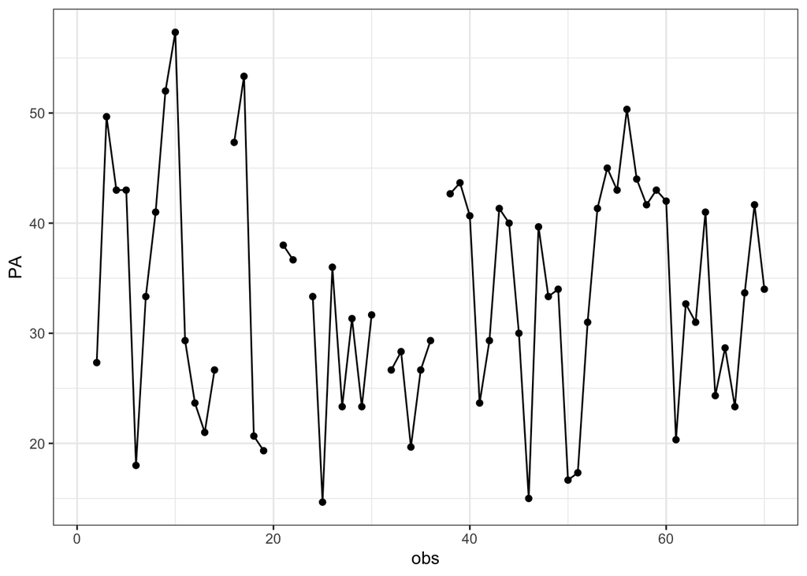

```r
# Plot the trajectories of the time-varying variable PA by person.
data %>%
    ggplot(aes(x = obs, y = PA)) +
    geom_point() +
    geom_line() +
    theme_bw()
```

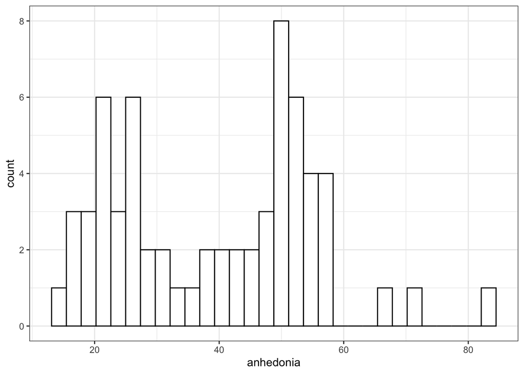

```r
# Histogram for the time-varying variable anhedonia.
ggplot(data, aes(anhedonia)) +
    geom_histogram(
        color = "black",
        fill = "white",
        bins = 30
    ) +
    theme_bw()
```

```r
# Descriptive statistics for anhedonia.
describe(data$anhedonia)
```

```
   vars  n  mean    sd median trimmed   mad min max range skew kurtosis   se
X1    1 64 39.34 15.84   41.5   38.92 20.02  14  83    69 0.22    -0.77 1.98
```

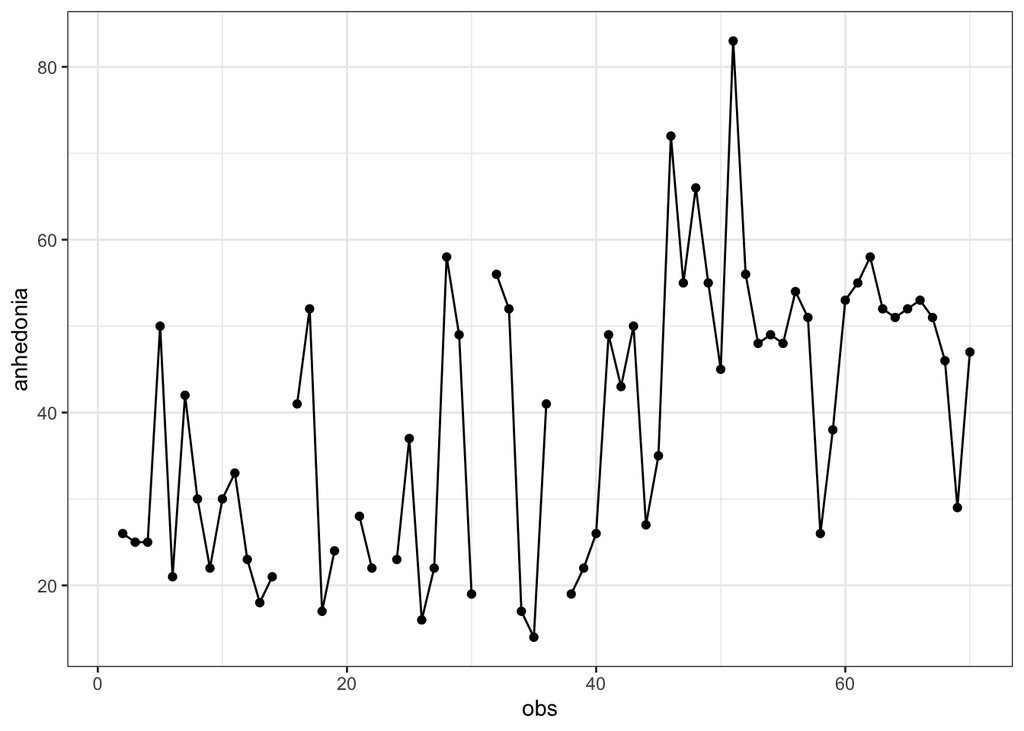

```r
# Plot the trajectories of the time-varying variable anhedonia by person.
data %>%
    ggplot(aes(x = obs, y = anhedonia)) +
    geom_point() +
    geom_line() +
    theme_bw()
```

## Data preparation

At this point, we are almost ready to start estimating our models. The last step before doing that, is creating the lagged version of the variables `PA` and `NA.`. They will be used on the subsequent $\text{AR}(1)$ and $\text{VAR}(1)$ models we fit below.

```r
# Create lagged variables.
# Lagged within days to take into account night breaks.
data$PA.lag <- rep(NA, nrow(data))
data$NA.lag <- rep(NA, nrow(data))
data$anhedonia.lag <- rep(NA, nrow(data))
day.id <- unique(data$day)

for (t in day.id) {
    data$PA.lag[which(data$day == t)] <- shift(data$PA[which(data$day == t)], 1)
    data$NA.lag[which(data$day == t)] <- shift(data$NA.[which(data$day == t)], 1)
    data$anhedonia.lag[which(data$day == t)] <- shift(data$anhedonia[which(data$day == t)], 1)
}
```

## Estimating $\text{AR}(1)$ for PA

We estimate an $\text{AR}(1)$ model for PA using a linear regression model (ordinary least squares, OLS). You can extract the estimates with the `summary()` function. Finally, you can compute the estimate of the standard deviation of the errors of the $\text{AR}(1)$ model computing the standard deviation using the function `sd()` on the residuals of the fitted model.

```r
# Fit AR(1) model for PA.
fit.AR.PA <- lm(PA ~ 1 + PA.lag, data = data)

# Show fit summary.
summary(fit.AR.PA)
```

```
Call:
lm(formula = PA ~ 1 + PA.lag, data = data)

Residuals:
    Min      1Q  Median      3Q     Max
-21.486  -5.866   2.070   5.820  18.155

Coefficients:
            Estimate Std. Error t value Pr(>|t|)
(Intercept)  20.3258     4.5755   4.442 4.68e-05 ***
PA.lag        0.4092     0.1308   3.130  0.00287 **
---
Signif. codes:  0 '***' 0.001 '**' 0.01 '*' 0.05 '.' 0.1 ' ' 1

Residual standard error: 9.658 on 52 degrees of freedom
  (16 observations deleted due to missingness)
Multiple R-squared:  0.1585,    Adjusted R-squared:  0.1423
F-statistic: 9.796 on 1 and 52 DF,  p-value: 0.002866
```

```r
# Estimate the standard deviation of the errors.
sd(residuals(fit.AR.PA))
```

```
[1] 9.566865
```

## Estimating $\text{VAR}(1)$ for PA and NA

We estimate a $\text{VAR}(1)$ model for PA and NA using two separate linear regression models. You can extract the estimates with the `summary()` function. Finally, you can compute the estimate of the variance-covariance matrix of the errors of the $\text{VAR}(1)$ model computing the covariance matrix using the function `cov()` on the residuals of each of the fitted models.

```r
# Linear regression model for PA.
fit.VAR.PA = lm(PA ~ 1 + PA.lag + NA.lag, data = data)

# Linear regression model for NA.
fit.VAR.NA = lm(NA. ~ 1 + PA.lag + NA.lag, data = data)

# Show fit summary for PA.
summary(fit.VAR.PA)
```

```
Call:
lm(formula = PA ~ 1 + PA.lag + NA.lag, data = data)

Residuals:
    Min      1Q  Median      3Q     Max
-21.551  -6.480   1.262   5.859  18.008

Coefficients:
            Estimate Std. Error t value Pr(>|t|)
(Intercept) 23.45530    6.27640   3.737 0.000471 ***
PA.lag       0.39213    0.13341   2.939 0.004930 **
NA.lag      -0.08273    0.11299  -0.732 0.467416
---
Signif. codes:  0 '***' 0.001 '**' 0.01 '*' 0.05 '.' 0.1 ' ' 1

Residual standard error: 9.702 on 51 degrees of freedom
  (16 observations deleted due to missingness)
Multiple R-squared:  0.1673,    Adjusted R-squared:  0.1346
F-statistic: 5.123 on 2 and 51 DF,  p-value: 0.009391
```

```r
# Show fit summary for NA.
summary(fit.VAR.NA)
```

```
Call:
lm(formula = NA. ~ 1 + PA.lag + NA.lag, data = data)

Residuals:
    Min      1Q  Median      3Q     Max
-14.260  -5.933  -2.073   3.104  39.302

Coefficients:
            Estimate Std. Error t value Pr(>|t|)
(Intercept)  17.8818     6.6337   2.696  0.00949 **
PA.lag       -0.0202     0.1410  -0.143  0.88664
NA.lag        0.3756     0.1194   3.145  0.00277 **
---
Signif. codes:  0 '***' 0.001 '**' 0.01 '*' 0.05 '.' 0.1 ' ' 1

Residual standard error: 10.25 on 51 degrees of freedom
  (16 observations deleted due to missingness)
Multiple R-squared:  0.1692,    Adjusted R-squared:  0.1366
F-statistic: 5.194 on 2 and 51 DF,  p-value: 0.008851
```

```r
# Estimate variance-covariance matrix of the errors.
res = cbind(residuals(fit.VAR.PA),residuals(fit.VAR.NA))

# Print the covariance matrix.
cov(res)
```

```
          [,1]       [,2]
[1,] 90.572865   4.295723
[2,]  4.295723 101.177796
```

## Estimating $\text{VAR}(1)$ model for NA, PA and anhedonia

We estimate a $\text{VAR}(1)$ model for PA, NA and anhedonia using three separate linear regression models. You can extract the estimates with the `summary()` function. Finally, you can compute the estimate of the variance-covariance matrix of the errors of the $\text{VAR}(1)$ model by computing the covariance matrix using the function `cov()` on the residuals of each of the fitted models.

```r
# Linear regression model for PA.
fit.VAR.PA = lm(PA ~ 1 + PA.lag + NA.lag + anhedonia.lag, data = data)

# Linear regression model for NA.
fit.VAR.NA = lm(NA. ~ 1 + PA.lag + NA.lag + anhedonia.lag, data = data)

# Linear regression model for anhedonia.
fit.VAR.anhedonia = lm(anhedonia ~ 1 + PA.lag + NA.lag + anhedonia.lag, data = data)

# Show fit summary for PA.
summary(fit.VAR.PA)
```

```
Call:
lm(formula = PA ~ 1 + PA.lag + NA.lag + anhedonia.lag, data = data)

Residuals:
    Min      1Q  Median      3Q     Max
-22.374  -5.907   1.342   5.856  18.787

Coefficients:
              Estimate Std. Error t value Pr(>|t|)
(Intercept)   22.60373    6.50921   3.473  0.00107 **
PA.lag         0.39067    0.13436   2.908  0.00542 **
NA.lag        -0.12662    0.13926  -0.909  0.36759
anhedonia.lag  0.05564    0.10179   0.547  0.58711
---
Signif. codes:  0 '***' 0.001 '**' 0.01 '*' 0.05 '.' 0.1 ' ' 1

Residual standard error: 9.769 on 50 degrees of freedom
  (16 observations deleted due to missingness)
Multiple R-squared:  0.1722,    Adjusted R-squared:  0.1226
F-statistic: 3.468 on 3 and 50 DF,  p-value: 0.02288
```

```r
# Show fit summary for NA.
summary(fit.VAR.NA)
```

```
Call:
lm(formula = NA. ~ 1 + PA.lag + NA.lag + anhedonia.lag, data = data)

Residuals:
    Min      1Q  Median      3Q     Max
-14.413  -5.302  -2.096   3.864  33.201

Coefficients:
              Estimate Std. Error t value Pr(>|t|)
(Intercept)   14.84269    6.66252   2.228   0.0304 *
PA.lag        -0.02541    0.13752  -0.185   0.8542
NA.lag         0.21894    0.14254   1.536   0.1309
anhedonia.lag  0.19856    0.10419   1.906   0.0624 .
---
Signif. codes:  0 '***' 0.001 '**' 0.01 '*' 0.05 '.' 0.1 ' ' 1

Residual standard error: 9.999 on 50 degrees of freedom
  (16 observations deleted due to missingness)
Multiple R-squared:  0.2255,    Adjusted R-squared:  0.179
F-statistic: 4.852 on 3 and 50 DF,  p-value: 0.00486
```

```r
# Show fit summary for anhedonia.
summary(fit.VAR.anhedonia)
```

```
Call:
lm(formula = anhedonia ~ 1 + PA.lag + NA.lag + anhedonia.lag,
    data = data)

Residuals:
    Min      1Q  Median      3Q     Max
-29.750  -9.599   1.195  10.194  29.364

Coefficients:
              Estimate Std. Error t value Pr(>|t|)
(Intercept)   14.94851    8.92402   1.675   0.1002
PA.lag         0.04386    0.18420   0.238   0.8128
NA.lag         0.32640    0.19093   1.710   0.0936 .
anhedonia.lag  0.30771    0.13955   2.205   0.0321 *
---
Signif. codes:  0 '***' 0.001 '**' 0.01 '*' 0.05 '.' 0.1 ' ' 1

Residual standard error: 13.39 on 50 degrees of freedom
  (16 observations deleted due to missingness)
Multiple R-squared:  0.268, Adjusted R-squared:  0.2241
F-statistic: 6.102 on 3 and 50 DF,  p-value: 0.001276
```

```r
# Estimate variance-covariance matrix of the errors.
res = cbind(residuals(fit.VAR.PA),residuals(fit.VAR.NA),residuals(fit.VAR.anhedonia))

# Print the covariance matrix.
cov(res)
```

```
          [,1]      [,2]      [,3]
[1,] 90.034929  2.375884  16.02124
[2,]  2.375884 94.326082  37.21901
[3,] 16.021244 37.219012 169.22933
```

## Running the `Shiny` application

The `Shiny` application is associated to a package that is stored at gitlab.kuleuven.be/ppw-okpiv/researchers/u0148925/shinyapp-paa_var_n1. To install the package and run the `Shiny` app, you can use the following `R` code:

```r
# Install the package containing the application.
remotes::install_gitlab(
    "ppw-okpiv/researchers/u0148925/shinyapp-paa_var_n1",
    host = "https://gitlab.kuleuven.be",
    force = TRUE
)

# Import the package containing the application.
library(paavar1)

# Run the shiny app.
run_paa_var1()
```

## Power analysis for $\text{VAR}(1)$ with three variables

**Exercise**

Try on your own and compare your results to the ones presented below!

### Power analysis result

Running the simulation with the application, you should end up with a similar plot as the one below.

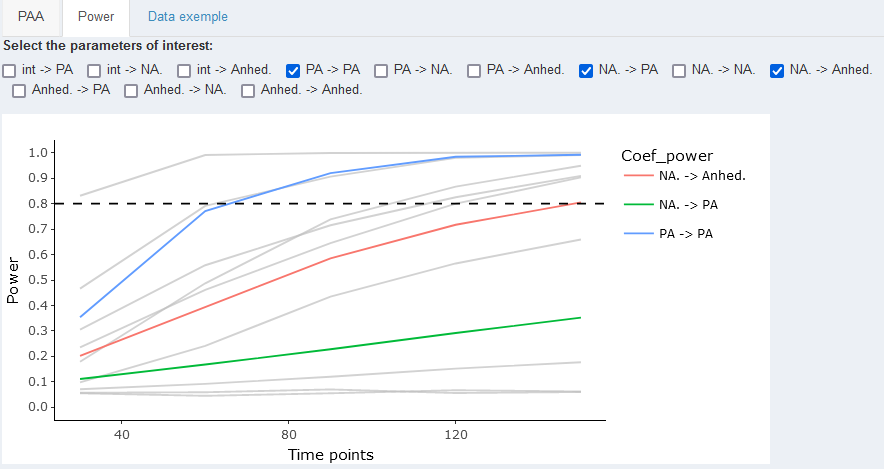

Power analysis $\text{VAR}(1)$ with three variables

### Sensitivity analysis for power: varying parameters

We slightly changed the values of three coefficients to investigate how they change either the sample size recommendation or the precision of estimates:

- $\beta_{11} = .39$ to $\beta_{11} = .8$
- $\sigma_{00} = 90$ to $\sigma_{00} = 180$
- $R = 1000$ to $R = 100$

**Exercise**

What conclusions can you draw based on the following power curves?

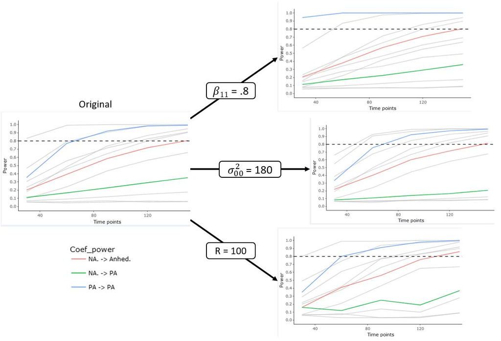

Sensitivity analysis for power

### Sensitivity analysis for power: using CI

Following Lafit, Revol et al. (under review), we run a sensitivity analysis using the upper and lower boundaries of the estimated coefficients of interest. First, we extract the 95% confidence interval of the estimated values of each parameter.

```r
# Linear regression model for PA.
confint(fit.VAR.PA, level = 0.95)

# Linear regression model for NA.
confint(fit.VAR.NA, level = 0.95)

# Linear regression model for anhedonia.
confint(fit.VAR.anhedonia, level = 0.95)
```

[output not shown]

We only varied the parameter values for the auto-regressive effect of PA ($\beta_{11}$) following the confidence interval. We run two new power analyses. The results are displayed below.

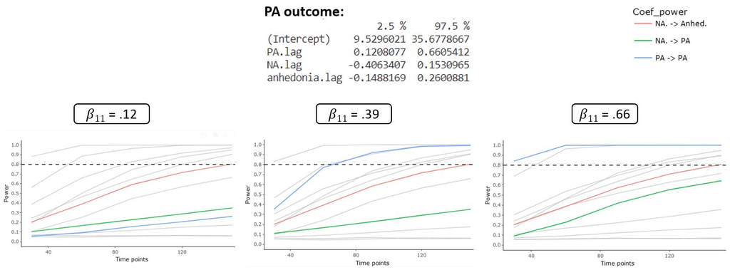

Sensitivity analysis for power

**Exercise**

What conclusions can you draw based on the following power curves?

## PAA for $\text{VAR}(1)$ with three variables

**Exercise**

Try on your own and compare your results to the ones presented below!

### PAA result

Running the simulation with the application, you should end up with a similar plot as the one below.

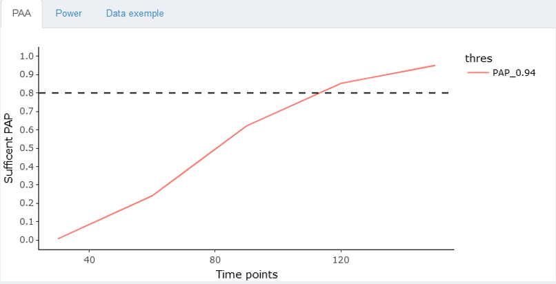

PAA for $\text{VAR}(1)$ with three variables

### Sensitivity analysis for power: varying parameters

We changed the values of the transition matrix to investigate how it changes the sample size recommendation.

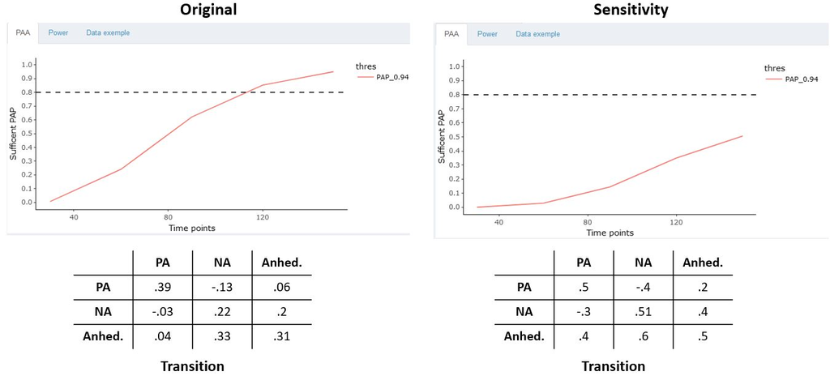

Sensitive PAA for $\text{VAR}(1)$

**Exercise**

What conclusions can you draw based on the following power curves?

**Note**

Despite the raising of the coefficients, the new transition matrix still fulfills the stationary assumption. Higher coefficients could lead to a violation of this assumption.

## References

Heininga, V. E., Dejonckheere, E., Houben, M., Obbels, J., Sienaert, P., Leroy, B., Roy, J. van, & Kuppens, P. (2019). The dynamical signature of anhedonia in major depressive disorder: Positive emotion dynamics, reactivity, and recovery. *BMC Psychiatry*, *19*(1), 59.

Rush, A. J., Trivedi, M. H., Ibrahim, H. M., Carmody, T. J., Arnow, B., Klein, D. N., Markowitz, J. C., Ninan, P. T., Kornstein, S., Manber, R., et al. (2003). The 16-item quick inventory of depressive symptomatology (QIDS), clinician rating (QIDS-c), and self-report (QIDS-SR): A psychometric evaluation in patients with chronic major depression. *Biological Psychiatry*, *54*(5), 573–583.